# G7 example

```r
knitr::opts_chunk$set(
  collapse = TRUE,
  comment = "#>",
  fig.align = "center",
  out.width = "90%"
)
```

```r
knitr::opts_chunk$set(echo = TRUE)
library(pbvar)
if (!requireNamespace("coda", quietly = TRUE)) {
  stop("Package 'coda' is required to build this vignette. Install it with install.packages('coda').")
}
if (!requireNamespace("lattice", quietly = TRUE)) {
  stop("Package 'lattice' is required to build this vignette. Install it with install.packages('lattice').")
}
```

# Preparing panel data for the model

This vignette shows how to prepare panel macroeconomic data, construct the country-level Y_g and Z_g matrices, run the hierarchical panel VAR sampler implemented in pbvar, and compute both group-level and global impulse response functions.

## Country-level data preparation

Each country is processed independently. For each one we:

1. Select the raw variables (GDP, CPI, Unemployment).
2. Apply the appropriate transformations:
   - log-difference × 100 for real GDP,
   - first differences for CPI and unemployment.
3. Align the data by removing the initial rows containing NAs.
4. Construct the matrices used in the VAR(1):
   - `Y_g = X_{t+1}` (dependent variables),
   - `Z_g = X_t` (lagged regressors).
5. Optionally demean the data (recommended for hierarchical pooling).

```r
data(panel_g7_bvar)

# USA
# Select the raw data for USA
df_USA <- panel_g7_bvar$USA

# Transformations:
# GDP_USA:   log-difference × 100   (quarterly growth rate)
# CPI_USA:   first difference       (already expressed in rates)
# U_USA:     first difference       (changes in unemployment)
df_USA$GDPd <- c(NA, diff(log(df_USA$GDP_USA)) * 100)
df_USA$CPId <- c(NA, diff(df_USA$CPI_USA))
df_USA$Ud   <- c(NA, diff(df_USA$U_USA))

# Remove first two rows (contain NA created by differencing/log-diff)
df_USA <- df_USA[-c(1, 2), ]

# Construct matrix of transformed variables in VAR order
# Here: GDPd (growth), CPId (inflation), Ud (unemployment changes)
M_USA <- as.matrix(df_USA[, c("GDPd", "CPId", "Ud")])
T_USA <- nrow(M_USA)

# Build Y_g and Z_g for a VAR(1):
# Y_g is X_{t}, Z_g is X_{t-1}
Y_USA <- M_USA[2:T_USA, ]
X_USA <- M_USA[1:(T_USA - 1), ]

# CAN
df_CAN <- panel_g7_bvar$CAN

df_CAN$GDPd <- c(NA, diff(log(df_CAN$GDP_CAN)) * 100)
df_CAN$CPId <- c(NA, diff(df_CAN$CPI_CAN))
df_CAN$Ud   <- c(NA, diff(df_CAN$U_CAN))

df_CAN <- df_CAN[-c(1, 2), ]

M_CAN <- as.matrix(df_CAN[, c("GDPd", "CPId", "Ud")])
T_CAN <- nrow(M_CAN)

Y_CAN <- M_CAN[2:T_CAN, ]
X_CAN <- M_CAN[1:(T_CAN - 1), ]

# GBR
df_GBR <- panel_g7_bvar$GBR

df_GBR$GDPd <- c(NA, diff(log(df_GBR$GDP_GBR)) * 100)
df_GBR$CPId <- c(NA, diff(df_GBR$CPI_GBR))
df_GBR$Ud   <- c(NA, diff(df_GBR$U_GBR))

df_GBR <- df_GBR[-c(1, 2), ]

M_GBR <- as.matrix(df_GBR[, c("GDPd", "CPId", "Ud")])
T_GBR <- nrow(M_GBR)

Y_GBR <- M_GBR[2:T_GBR, ]
X_GBR <- M_GBR[1:(T_GBR - 1), ]

# DEU
df_DEU <- panel_g7_bvar$DEU

df_DEU$GDPd <- c(NA, diff(log(df_DEU$GDP_DEU)) * 100)
df_DEU$CPId <- c(NA, diff(df_DEU$CPI_DEU))
df_DEU$Ud   <- c(NA, diff(df_DEU$U_DEU))

df_DEU <- df_DEU[-c(1, 2), ]

M_DEU <- as.matrix(df_DEU[, c("GDPd", "CPId", "Ud")])
T_DEU <- nrow(M_DEU)

Y_DEU <- M_DEU[2:T_DEU, ]
X_DEU <- M_DEU[1:(T_DEU - 1), ]

# FRA
df_FRA <- panel_g7_bvar$FRA

df_FRA$GDPd <- c(NA, diff(log(df_FRA$GDP_FRA)) * 100)
df_FRA$CPId <- c(NA, diff(df_FRA$CPI_FRA))
df_FRA$Ud   <- c(NA, diff(df_FRA$U_FRA))

df_FRA <- df_FRA[-c(1, 2), ]

M_FRA <- as.matrix(df_FRA[, c("GDPd", "CPId", "Ud")])
T_FRA <- nrow(M_FRA)

Y_FRA <- M_FRA[2:T_FRA, ]
X_FRA <- M_FRA[1:(T_FRA - 1), ]

# ITA
df_ITA <- panel_g7_bvar$ITA

df_ITA$GDPd <- c(NA, diff(log(df_ITA$GDP_ITA)) * 100)
df_ITA$CPId <- c(NA, diff(df_ITA$CPI_ITA))
df_ITA$Ud   <- c(NA, diff(df_ITA$U_ITA))

df_ITA <- df_ITA[-c(1, 2), ]

M_ITA <- as.matrix(df_ITA[, c("GDPd", "CPId", "Ud")])
T_ITA <- nrow(M_ITA)

Y_ITA <- M_ITA[2:T_ITA, ]
X_ITA <- M_ITA[1:(T_ITA - 1), ]

# JPN
df_JPN <- panel_g7_bvar$JPN

df_JPN$GDPd <- c(NA, diff(log(df_JPN$GDP_JPN)) * 100)
df_JPN$CPId <- c(NA, diff(df_JPN$CPI_JPN))
df_JPN$Ud   <- c(NA, diff(df_JPN$U_JPN))

df_JPN <- df_JPN[-c(1, 2), ]

M_JPN <- as.matrix(df_JPN[, c("GDPd", "CPId", "Ud")])
T_JPN <- nrow(M_JPN)

Y_JPN <- M_JPN[2:T_JPN, ]
X_JPN <- M_JPN[1:(T_JPN - 1), ]

Yg_list <- list(
  Y_USA,Y_CAN,Y_GBR,Y_DEU,
  Y_FRA,Y_ITA,Y_JPN
)

Xg_list <- list(
  X_USA,X_CAN,X_GBR,X_DEU,
  X_FRA,X_ITA,X_JPN
)
```

## Demeaning the data

Before running the sampler we remove the country-specific means from each series. Since the transformed variables (GDP growth, inflation changes and unemployment changes) are already stationary and fluctuate around stable means, demeaning is appropriate and avoids the need for explicit intercept terms in the VAR.

```r
Yg_list <- unname(Yg_list)
Xg_list <- unname(Xg_list)

# Demean each country-specific block
Yg_list_demean <- lapply(Yg_list, function(Y) scale(Y, center = TRUE, scale = FALSE))
Xg_list_demean <- lapply(Xg_list, function(X) scale(X, center = TRUE, scale = FALSE))
```

## Running the MCMC sampler

In this section, we launch the MCMC sampler with the following specifications to reduce computational costs: $R = 2000$, $burnin = 500$, $thin = 5$, $nChains = 2$. We estimate a VAR(1)

```r
lag        <- 1
fixed_list <- NULL
R          <- 2000
burnin     <- 500
thin       <- 5
nChains    <- 2

var_names     <- c("GDP", "CPI", "U")
lag_names     <- paste0(var_names, "_lag1")
country_names <- c("USA","CAN","GBR","DEU","FRA","ITA","JPN")

mcmc_out <- run_mcmc(Yg_list_demean, Xg_list_demean, lag, fixed_list,
                     R, burnin, thin, nChains,
                     var_names, lag_names, country_names)
```

## MCMC summary and diagnostic

We extract the chains and proceed with the following diagnostic checks:

1. Convergence to stationary distribution (Rhat)
2. Number of uncorrelated samples (ESS)
3. Positive definite variance matrices
4. Stationarity of the model
5. Check on the effect of pooling

```r
chains  <- mcmc_out$CHAINS
nChains <- length(chains)

var_names     <- c("GDP", "CPI", "U")
lag_names     <- paste0(var_names, "_lag1")
country_names <- c("USA","CAN","GBR","DEU","FRA","ITA","JPN")

par <- summary_par(chains,var_names,lag_names,country_names, par = "all")

tabA    <-par$A
tabAg   <-par$Ag
tabSg   <-par$Sg
tabSigma<-par$Sigma
tabV    <-par$V
```

We verify that the series are convergent by checking the deviation from 1 of the Rhat:

```r
# A
mean(abs(tabA$Rhat-1))
```

```
#> [1] 0.004985111
```

```r
sum(abs(tabA$Rhat-1)>0.1)
```

```
#> [1] 0
```

```r
#Ag
mean(abs(tabAg$Rhat-1))
```

```
#> [1] 0.002851189
```

```r
sum(abs(tabAg$Rhat-1)>0.1)
```

```
#> [1] 0
```

```r
#Sg
mean(abs(tabSg$Rhat-1))
```

```
#> [1] 0.002708183
```

```r
sum(abs(tabSg$Rhat-1)>0.1)
```

```
#> [1] 0
```

```r
#Sigma
mean(abs(tabSigma$Rhat-1))
```

```
#> [1] 0.000641699
```

```r
sum(abs(tabSigma$Rhat-1)>0.1)
```

```
#> [1] 0
```

```r
#V
mean(abs(tabV$Rhat-1))
```

```
#> [1] 0.00733652
```

```r
sum(abs(tabV$Rhat-1)>0.1)
```

```
#> [1] 0
```

None of the parameters deviate from $1$, so we can say that there is convergence to the stationary distribution.

Now let’s consider the effective sample size (ESS):

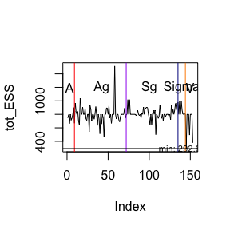

```r
tot_ESS<-c(tabA$ESS,tabAg$ESS,tabSg$ESS,
           tabSigma$ESS,tabV$ESS)
plot(tot_ESS,type='l')
abline(v=9,col='red')
abline(v=(9+63),col='purple')
abline(v=(9+63+63),col='dark blue')
abline(v=(9+9+63+63),col='dark orange')
text(3,1200,'A')
text(42,1200,'Ag')
text(100,1200,'Sg')
text(139.5,1200,'Sigma')
text(150,1200,'V')
abline(h=min(tot_ESS))
text(which.min(tot_ESS)+1, min(tot_ESS)-.5,'min: 292.6293',cex=.7)
```

The x-axis is an index representing the position of the parameter in the concatenated vector. The vertical lines highlight the boundaries between the parameter blocks. The algorithm has good overall efficiency. Most parameters have ESS between 700 and 1000+.

Finally, we check that the variance matrices are positive definite and that there are no unit roots in $Ag$ and $A$.

```r
# Positive definite check
mat<-list(
  meanV<-matrix(tabV[,2],ncol=3),
  meanSig<-matrix(tabSigma[,2],ncol=3),
  meanSg<-array(tabSg[,2],c(3,3,7)))

defpos<-function(mat,indx){
  if(is.na(dim(mat[[indx]])[3])){
    if(sum(eigen(mat[[indx]])$values>0)!=3){
      cat("There is a problem in the matrix", indx,'\n',
         'The eigenvalues of the matrix are', eigen(mat[[indx]])$values,'\n')}
    else cat('The matrix is positive definite')
  }
  else{
    for(j in 1:7){
      if(sum(eigen(mat[[indx]][,,j])$values>0)!=3){
        cat("There is a problem in the matrix", i,'\n',
            'The eigenvalues of the group matrix',j,' are', eigen(mat[[indx]][,,j])$values,'\n')
      }
      else cat('The matrix is positive definite \n')
    }
  }

}

defpos(mat,1)
```

```
#> The matrix is positive definite
```

```r
defpos(mat,2)
```

```
#> The matrix is positive definite
```

```r
defpos(mat,3)
```

```
#> The matrix is positive definite
#> The matrix is positive definite
#> The matrix is positive definite
#> The matrix is positive definite
#> The matrix is positive definite
#> The matrix is positive definite
#> The matrix is positive definite
```

```r
# unit roots check
K <- 3
G <- length(country_names)

A_mean <- matrix(tabA$mean, nrow = K, byrow = TRUE)
A_mean
```

```
#>              [,1]         [,2]        [,3]
#> [1,]  0.350606680  0.173382934 -0.08713737
#> [2,]  0.008574543  0.104208007 -0.01839629
#> [3,] -0.331044913 -0.006923427  0.46031127
```

```r
ev_A   <- eigen(A_mean)$values
mod_A  <- Mod(ev_A)
ev_A
```

```
#> [1] 0.5911913 0.2100176 0.1139170
```

```r
mod_A
```

```
#> [1] 0.5911913 0.2100176 0.1139170
```

```r
max(mod_A)
```

```
#> [1] 0.5911913
```

```r
max_mod_g <- c(G)
for (g in seq_along(country_names)) {

  idx <- ((g - 1) * K * K + 1):(g * K * K)
  Ag_mean_g <- matrix(tabAg$mean[idx], nrow = K, byrow = TRUE)

  ev  <- eigen(Ag_mean_g)$values
  mod <- Mod(ev)

  max_mod_g[g] <- max(mod)
}

max_mod_g
```

```
#> [1] 0.6634470 0.5632877 0.7154720 0.6535047 0.5291445 0.6383495 0.4931266
```

The are not unit roots, the model is stationary.

To verify the effect of pooling we evaluate the L2 norm among country-specific matrices relative to the generic estimate: $\|A_g - A\| = \sqrt{\sum_{i,j} (A_{g,ij} - A_{ij})^2}$

```r
tot_Ag <- array(tabAg$mean,dim=c(3,3,7))
matA   <-matrix(tabA$mean,ncol=3)

colnames(matA) <- c('GDP_lag1','CPI_lag1','U_lag1')
rownames(matA) <- c('GDP','CPI','U')

dimnames(tot_Ag) <- list(
  rownames = c('GDP','CPI','U'),
  colnames = c('GDP_lag1','CPI_lag1','U_lag1'),
  znames   = c("USA", "CAN","GBR","DEU","FRA","ITA","JPN")
)

apply(tot_Ag,3,function(x) sqrt(sum((x-matA)^2)))
```

```
#>       USA       CAN       GBR       DEU       FRA       ITA       JPN
#> 0.2035064 0.1941191 0.2350941 0.3805383 0.2162471 0.2306681 0.4183381
```

Germany and Japan are the countries that deviate most from global estimates, while the others follow the global dynamic.

## Global-level IRFs

We represent global IRFs and verify that their performance is consistent with economic theory expectations.

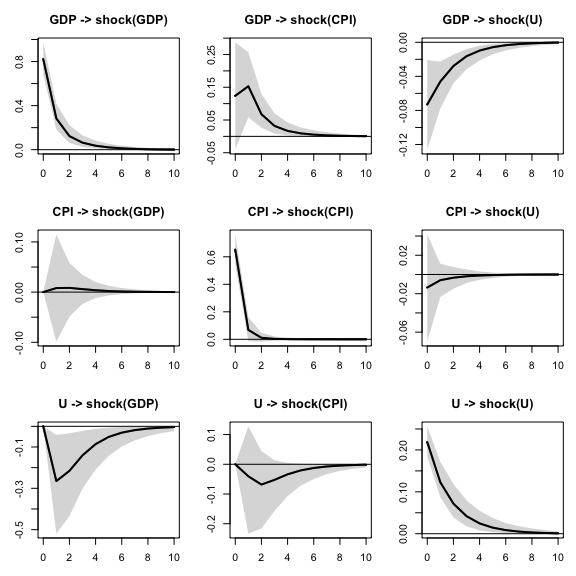

```r
H <- 10

global_irfs <- compute_global_irf(chains,H)

plot_global_irf(global_irfs, var_names)
```

### GDP’s shocks

1. *GDP $\leftarrow$ shock(GDP)* : the sign is positive and decays quickly. The shock that moves GDP has only short-term effects.
2. *CPI $\leftarrow$ shock(GDP)* : very small response, centred around zero.
3. *U $\leftarrow$ shock(GDP)*: decreases in the early periods, then rises again, consistent with a demand shock that reduces unemployment.

### U’s shocks

1. *GDP $\leftarrow$ shock(U)*: small negative response at the outset, consistent with the idea that an increase in unemployment signals an initial slowdown in activity.
2. *CPI $\leftarrow$ shock(U)*: response very close to zero. No clear effect on price dynamics.
3. *U $\leftarrow$ shock(U)*: strong impulse in the first period, then decays towards 0.